# NHS Borders | Cancer Incidence Rates

## 1. Introduction and Aims

### Brief

In order to help inform the planning for provision of cancer treatment services in NHS Borders, we would like to gain better understanding of the incidence of cancer in NHS Borders.

### Investigation Aims

The aims of this investigation are to answer the following questions:

1. What is the trend in cancer incidence over the period?
2. What types of cancer are the most common?
3. What types of cancer have the highest increase in incidence rate over the period?
4. Which types of cancer are most prevalent among men?
5. Which types of cancer are most prevalent among women?

## 2. Analysis

### 1. What is the trend in cancer incidence over the period (1994 - 2018)?

One of the cancer sites listed in the data was “All cancer types”. By filtering for this condition an overview of all cancer incidences for all sexes can be plotted:

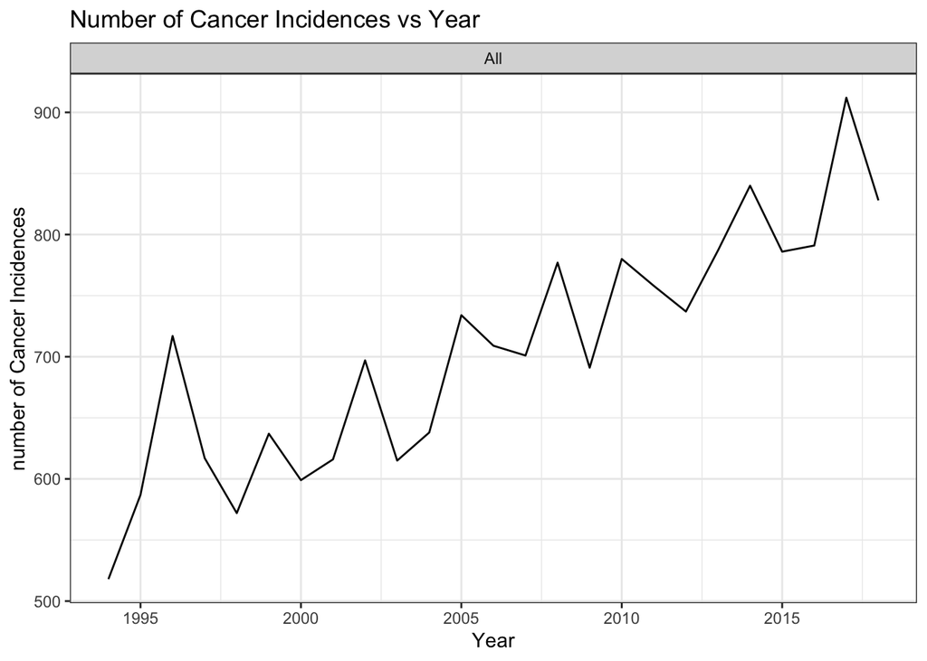

One of the variables was sex, so the same plot could be split into the two sexes for a more specific picture:

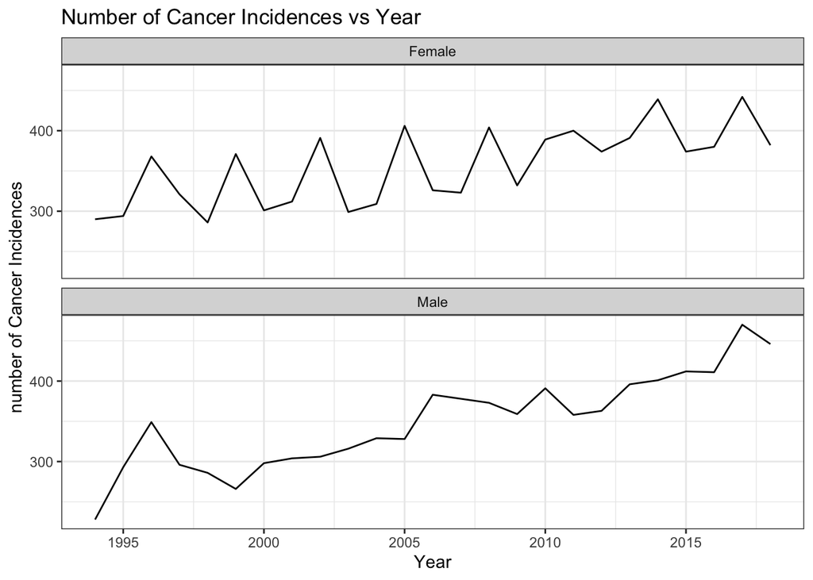

Using total cancer incidences for each year provides a general overview. A more specific overview could use the crude rate, which is a measure which takes the population into account.

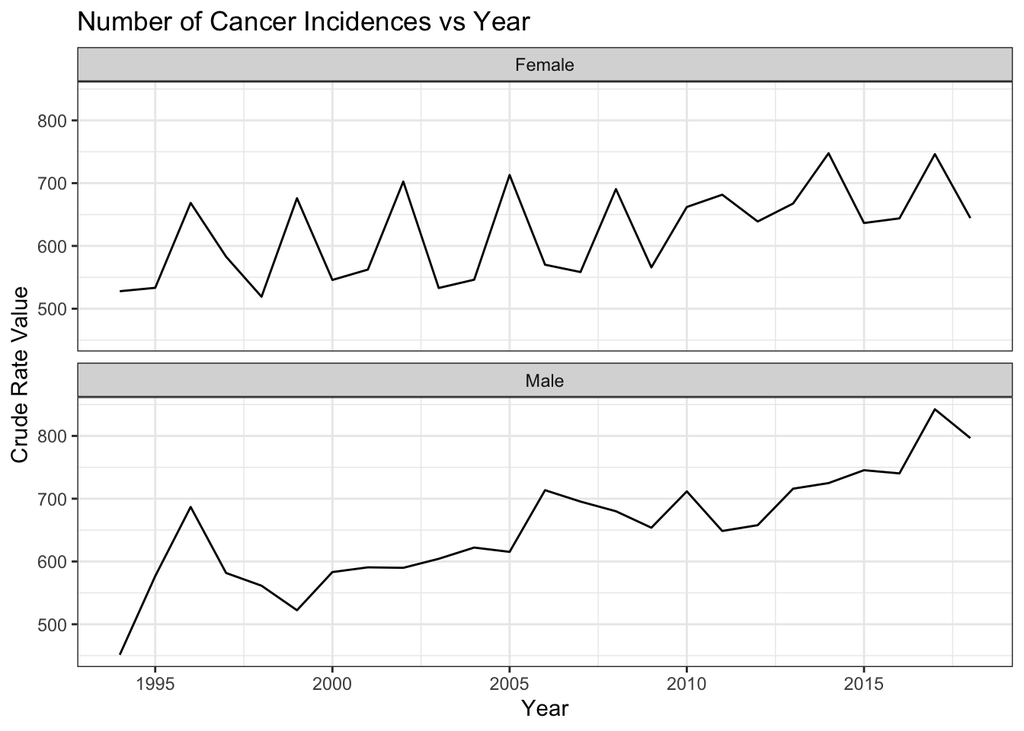

If it were the case that cancer incidence was increasing due to the nature of an increase in population alone, this line would be flat.

### 2. Which types of cancer are the most common?

After filtering the data, this table was generated. It shows the cancer site ( type of cancer) and the number of recorded incidences for the period (1994 - 2018)

| Cancer Site | Total Incidences |
| --- | --- |
| Non-melanoma skin cancer | 11482 |
| Basal cell carcinoma of the skin | 7650 |
| Breast | 4948 |
| Colorectal cancer | 4872 |
| Trachea, bronchus and lung | 4862 |
| Squamous cell carcinoma of the skin | 3544 |
| Colon | 3173 |
| Prostate | 2119 |
| Carcinoma in situ of the cervix uteri | 1386 |
| Rectum and rectosigmoid junction | 1087 |

[figure not shown]

For a more in depth understanding of the most common cancer types, the ten with the highest number of total incidences over the period (1994 - 2018) can be plotted:

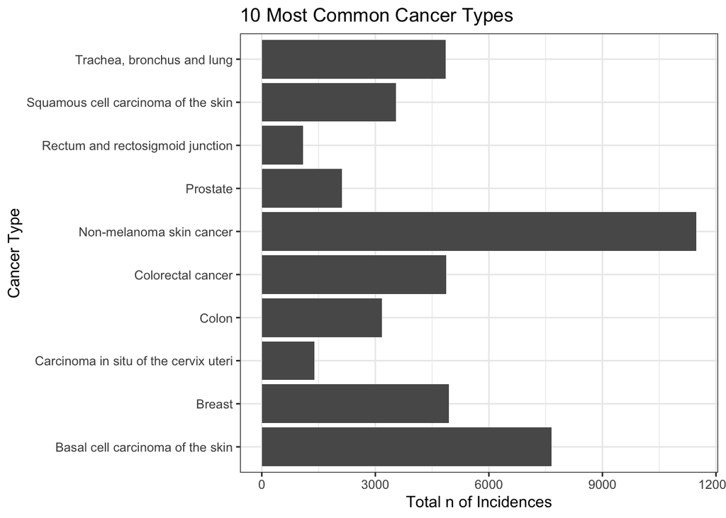

### 3. Which types of cancer have the highest increase in incidence rate over the period (1994 - 2018)?

Examination of crude rates:

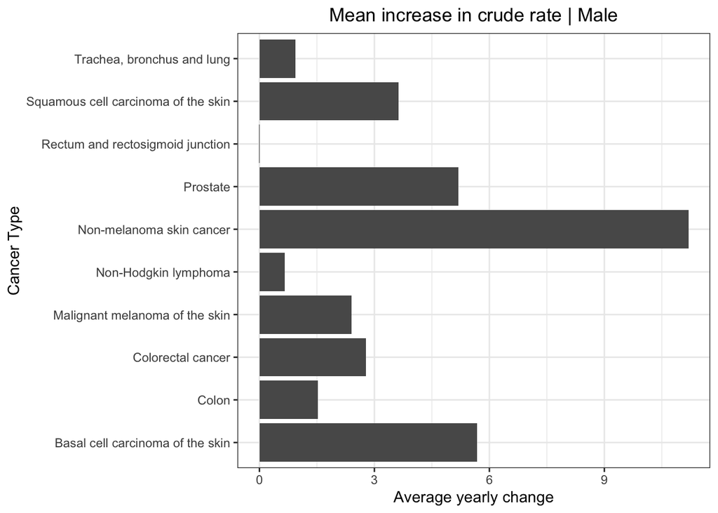

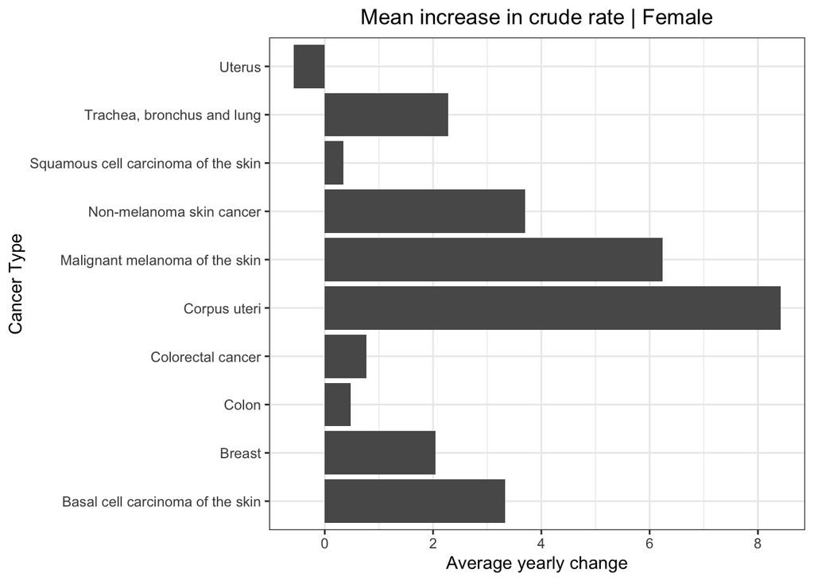

### 4. Which types of cancer are most prevalent among men?

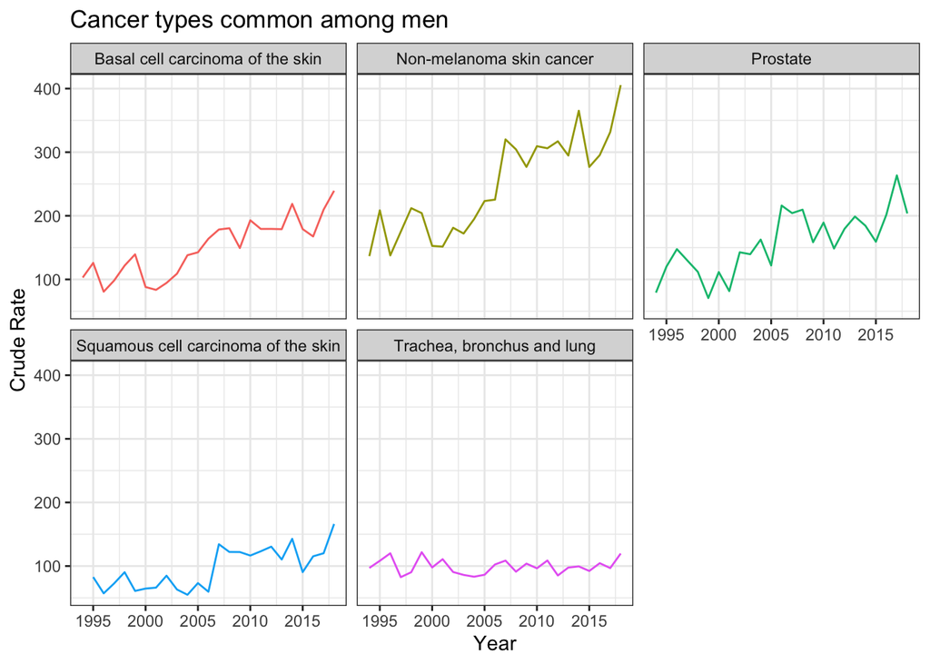

### 5. Which types of cancer are most prevalent among women?

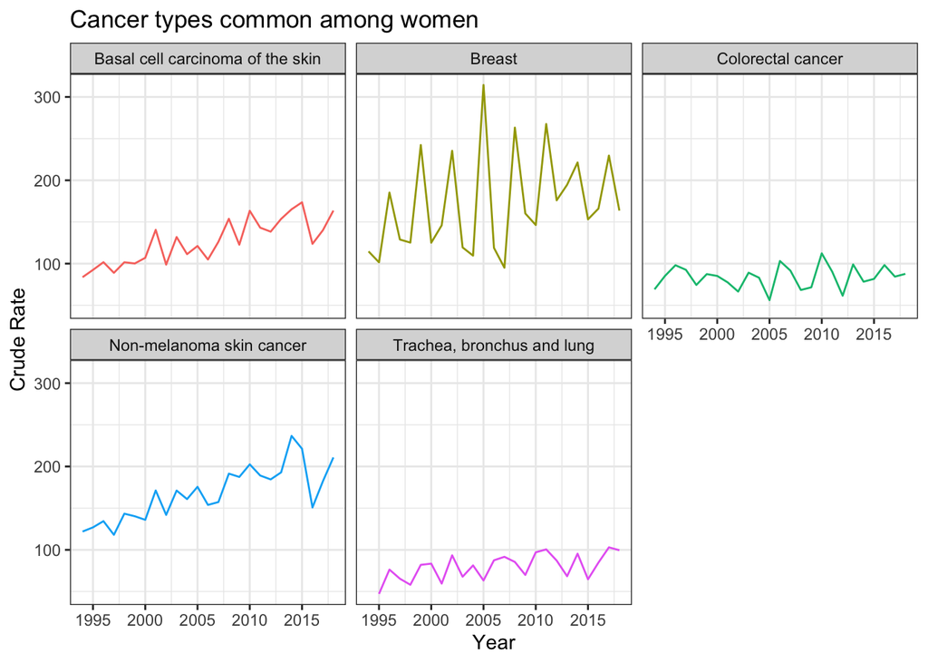

### Combined Plot

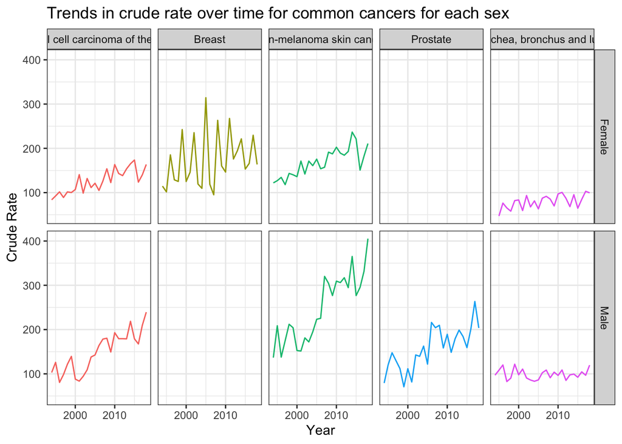